# Selecting and renaming columns

The GRAPH Courses team

November 2022

# 1 Introduction

Today we will begin our exploration of the {dplyr} package! Our first verb on the list is `select` which allows to keep or drop variables from your dataframe. Choosing your variables is the first step in cleaning your data.

[figure not shown]

Fig: the `select()` function.

Let’s go !

# 2 Learning objectives

- You can keep or drop columns from a dataframe using the `dplyr::select()` function from the {dplyr} package.
- You can select a range or combination of columns using operators like the colon (`:`), the exclamation mark (`!`), and the `c()` function.
- You can select columns based on patterns in their names with helper functions like `starts_with()`, `ends_with()`, `contains()`, and `everything()`.
- You can use `rename()` and `select()` to change column names.

# 3 The Yaounde COVID-19 dataset

In this lesson, we analyse results from a COVID-19 serological survey conducted in Yaounde, Cameroon in late 2020. The survey estimated how many people had been infected with COVID-19 in the region, by testing for IgG and IgM antibodies. The full dataset can be obtained from [Zenodo](https://zenodo.org/record/5218965), and the paper can be viewed [here](https://www.nature.com/articles/s41467-021-25946-0).

Spend some time browsing through this dataset. Each line corresponds to one patient surveyed. There are some demographic, socio-economic and COVID-related variables. The results of the IgG and IgM antibody tests are in the columns `igg_result` and `igm_result`.

```r
yaounde <- read_csv(here::here("data/yaounde_data.csv"))
yaounde
```

```
## # A tibble: 5 × 53
##   id                   date_surveyed   age age_category
##   <chr>                <date>        <dbl> <chr>
## 1 BRIQUETERIE_000_0001 2020-10-22       45 45 - 64
## 2 BRIQUETERIE_000_0002 2020-10-24       55 45 - 64
## 3 BRIQUETERIE_000_0003 2020-10-24       23 15 - 29
## 4 BRIQUETERIE_002_0001 2020-10-22       20 15 - 29
## 5 BRIQUETERIE_002_0002 2020-10-22       55 45 - 64
## # … with 49 more variables: age_category_3 <chr>,
## #   sex <chr>, highest_education <chr>, occupation <chr>, …
```

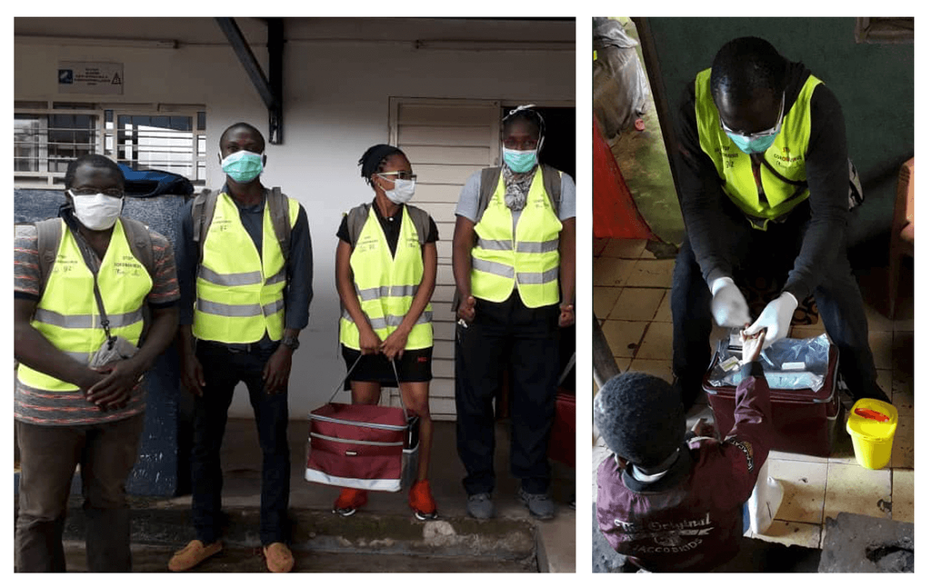

Left: the Yaounde survey team. Right: an antibody test being administered.

# 4 Introducing `select()`

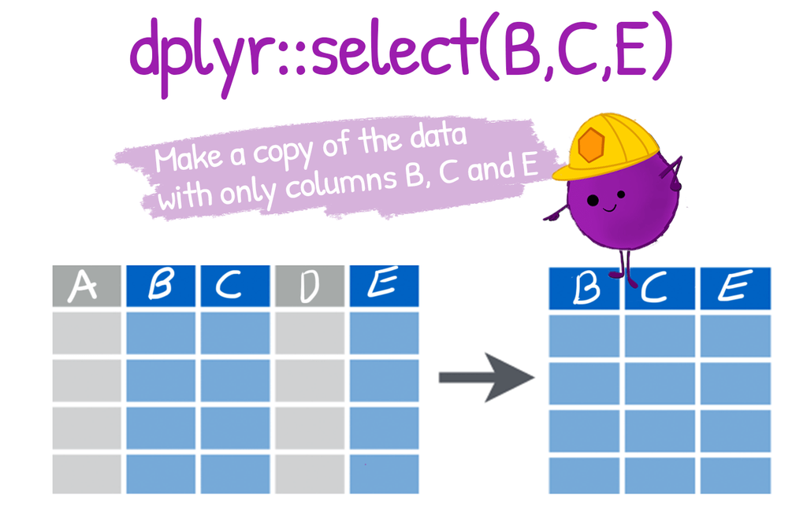

Fig: the `select()` function. (Drawing adapted from Allison Horst).

`dplyr::select()` lets us pick which columns (variables) to keep or drop.

We can select a column **by name**:

```r
yaounde %>% select(age)
```

```
## # A tibble: 5 × 1
##     age
##   <dbl>
## 1    45
## 2    55
## 3    23
## 4    20
## 5    55
```

Or we can select a column **by position**:

```r
yaounde %>% select(3) # `age` is the 3rd column
```

```
## # A tibble: 5 × 1
##     age
##   <dbl>
## 1    45
## 2    55
## 3    23
## 4    20
## 5    55
```

To select **multiple variables**, we separate them with commas:

```r
yaounde %>% select(age, sex, igg_result)
```

[output not shown]

- Select the weight and height variables in the `yaounde` data frame.
- Select the 16th and 22nd columns in the `yaounde` data frame.

For the next part of the tutorial, let’s create a smaller subset of the data, called `yao`.

```r
yao <-
  yaounde %>% select(age,
                     sex,
                     highest_education,
                     occupation,
                     is_smoker,
                     is_pregnant,
                     igg_result,
                     igm_result)
yao
```

```
## # A tibble: 5 × 8
##     age sex    highest_education occupation      is_smoker
##   <dbl> <chr>  <chr>             <chr>           <chr>
## 1    45 Female Secondary         Informal worker Non-smoker
## 2    55 Male   University        Salaried worker Ex-smoker
## 3    23 Male   University        Student         Smoker
## 4    20 Female Secondary         Student         Non-smoker
## 5    55 Female Primary           Trader--Farmer  Non-smoker
## # … with 3 more variables: is_pregnant <chr>,
## #   igg_result <chr>, igm_result <chr>
```

## 4.1 Selecting column ranges with `:`

The `:` operator selects a **range of consecutive variables**:

```r
yao %>% select(age:occupation) # Select all columns from `age` to `occupation`
```

```
## # A tibble: 5 × 4
##     age sex    highest_education occupation
##   <dbl> <chr>  <chr>             <chr>
## 1    45 Female Secondary         Informal worker
## 2    55 Male   University        Salaried worker
## 3    23 Male   University        Student
## 4    20 Female Secondary         Student
## 5    55 Female Primary           Trader--Farmer
```

We can also specify a range with column numbers:

```r
yao %>% select(1:4) # Select columns 1 to 4
```

```
## # A tibble: 5 × 4
##     age sex    highest_education occupation
##   <dbl> <chr>  <chr>             <chr>
## 1    45 Female Secondary         Informal worker
## 2    55 Male   University        Salaried worker
## 3    23 Male   University        Student
## 4    20 Female Secondary         Student
## 5    55 Female Primary           Trader--Farmer
```

- With the `yaounde` data frame, select the columns between `symptoms` and `sequelae`, inclusive. (“Inclusive” means you should also include `symptoms` and `sequelae` in the selection.)

## 4.2 Excluding columns with `!`

The **exclamation point** negates a selection:

```r
yao %>% select(!age) # Select all columns except `age`
```

```
## # A tibble: 5 × 7
##   sex    highest_education occupation      is_smoker
##   <chr>  <chr>             <chr>           <chr>
## 1 Female Secondary         Informal worker Non-smoker
## 2 Male   University        Salaried worker Ex-smoker
## 3 Male   University        Student         Smoker
## 4 Female Secondary         Student         Non-smoker
## 5 Female Primary           Trader--Farmer  Non-smoker
## # … with 3 more variables: is_pregnant <chr>,
## #   igg_result <chr>, igm_result <chr>
```

To drop a range of consecutive columns, we use, for example,`!age:occupation`:

```r
yao %>% select(!age:occupation) # Drop columns from `age` to `occupation`
```

```
## # A tibble: 5 × 4
##   is_smoker  is_pregnant igg_result igm_result
##   <chr>      <chr>       <chr>      <chr>
## 1 Non-smoker No          Negative   Negative
## 2 Ex-smoker  <NA>        Positive   Negative
## 3 Smoker     <NA>        Negative   Negative
## 4 Non-smoker No          Positive   Negative
## 5 Non-smoker No          Positive   Negative
```

To drop several non-consecutive columns, place them inside `!c()`:

```r
yao %>% select(!c(age, sex, igg_result))
```

```
## # A tibble: 5 × 5
##   highest_education occupation      is_smoker  is_pregnant
##   <chr>             <chr>           <chr>      <chr>
## 1 Secondary         Informal worker Non-smoker No
## 2 University        Salaried worker Ex-smoker  <NA>
## 3 University        Student         Smoker     <NA>
## 4 Secondary         Student         Non-smoker No
## 5 Primary           Trader--Farmer  Non-smoker No
## # … with 1 more variable: igm_result <chr>
```

- From the `yaounde` data frame, **remove** all columns between `highest_education` and `consultation`, inclusive.

# 5 Helper functions for `select()`

`dplyr` has a number of helper functions to make selecting easier by using patterns from the column names. Let’s take a look at some of these.

## 5.1 `starts_with()` and `ends_with()`

These two helpers work exactly as their names suggest!

```r
yao %>% select(starts_with("is_")) # Columns that start with "is"
```

```
## # A tibble: 5 × 2
##   is_smoker  is_pregnant
##   <chr>      <chr>
## 1 Non-smoker No
## 2 Ex-smoker  <NA>
## 3 Smoker     <NA>
## 4 Non-smoker No
## 5 Non-smoker No
```

```r
yao %>% select(ends_with("_result")) # Columns that end with "result"
```

```
## # A tibble: 5 × 2
##   igg_result igm_result
##   <chr>      <chr>
## 1 Negative   Negative
## 2 Positive   Negative
## 3 Negative   Negative
## 4 Positive   Negative
## 5 Positive   Negative
```

## 5.2 `contains()`

`contains()` helps select columns that contain a certain string:

```r
yaounde %>% select(contains("drug")) # Columns that contain the string "drug"
```

```
## # A tibble: 5 × 12
##   drugsource       is_drug_parac is_drug_antibio
##   <chr>                    <dbl>           <dbl>
## 1 Self or familial             1               0
## 2 <NA>                        NA              NA
## 3 <NA>                        NA              NA
## 4 Self or familial             0               1
## 5 <NA>                        NA              NA
## # … with 9 more variables: is_drug_hydrocortisone <dbl>,
## #   is_drug_other_anti_inflam <dbl>, …
```

## 5.3 `everything()`

Another helper function, `everything()`, matches all variables that have not yet been selected.

```r
# First, `is_pregnant`, then every other column.
yao %>% select(is_pregnant, everything())
```

```
## # A tibble: 5 × 8
##   is_pregnant   age sex    highest_education occupation
##   <chr>       <dbl> <chr>  <chr>             <chr>
## 1 No             45 Female Secondary         Informal worker
## 2 <NA>           55 Male   University        Salaried worker
## 3 <NA>           23 Male   University        Student
## 4 No             20 Female Secondary         Student
## 5 No             55 Female Primary           Trader--Farmer
## # … with 3 more variables: is_smoker <chr>,
## #   igg_result <chr>, igm_result <chr>
```

It is often useful for establishing the order of columns.

Say we wanted to bring the `is_pregnant` column to the start of the `yao` data frame, we could type out all the column names manually:

```r
yao %>% select(is_pregnant,
               age,
               sex,
               highest_education,
               occupation,
               is_smoker,
               igg_result,
               igm_result)
```

```
## # A tibble: 5 × 8
##   is_pregnant   age sex    highest_education occupation
##   <chr>       <dbl> <chr>  <chr>             <chr>
## 1 No             45 Female Secondary         Informal worker
## 2 <NA>           55 Male   University        Salaried worker
## 3 <NA>           23 Male   University        Student
## 4 No             20 Female Secondary         Student
## 5 No             55 Female Primary           Trader--Farmer
## # … with 3 more variables: is_smoker <chr>,
## #   igg_result <chr>, igm_result <chr>
```

But this would be painful for larger data frames, such as our original `yaounde` data frame. In such a case, we can use `everything()`:

```r
# Bring `is_pregnant` to the front of the data frame
yaounde %>% select(is_pregnant, everything())
```

```
## # A tibble: 5 × 53
##   is_pregnant id                   date_surveyed   age
##   <chr>       <chr>                <date>        <dbl>
## 1 No          BRIQUETERIE_000_0001 2020-10-22       45
## 2 <NA>        BRIQUETERIE_000_0002 2020-10-24       55
## 3 <NA>        BRIQUETERIE_000_0003 2020-10-24       23
## 4 No          BRIQUETERIE_002_0001 2020-10-22       20
## 5 No          BRIQUETERIE_002_0002 2020-10-22       55
## # … with 49 more variables: age_category <chr>,
## #   age_category_3 <chr>, sex <chr>, …
```

This helper can be combined with many others.

```r
# Bring columns that end with "result" to the front of the data frame
yaounde %>% select(ends_with("result"), everything())
```

```
## # A tibble: 5 × 53
##   igg_result igm_result id               date_surveyed   age
##   <chr>      <chr>      <chr>            <date>        <dbl>
## 1 Negative   Negative   BRIQUETERIE_000… 2020-10-22       45
## 2 Positive   Negative   BRIQUETERIE_000… 2020-10-24       55
## 3 Negative   Negative   BRIQUETERIE_000… 2020-10-24       23
## 4 Positive   Negative   BRIQUETERIE_002… 2020-10-22       20
## 5 Positive   Negative   BRIQUETERIE_002… 2020-10-22       55
## # … with 48 more variables: age_category <chr>,
## #   age_category_3 <chr>, sex <chr>, …
```

- Select all columns in the `yaounde` data frame that start with “is_”.
- Move the columns that start with “is_” to the beginning of the `yaounde` data frame.

# 6 Change column names with `rename()`

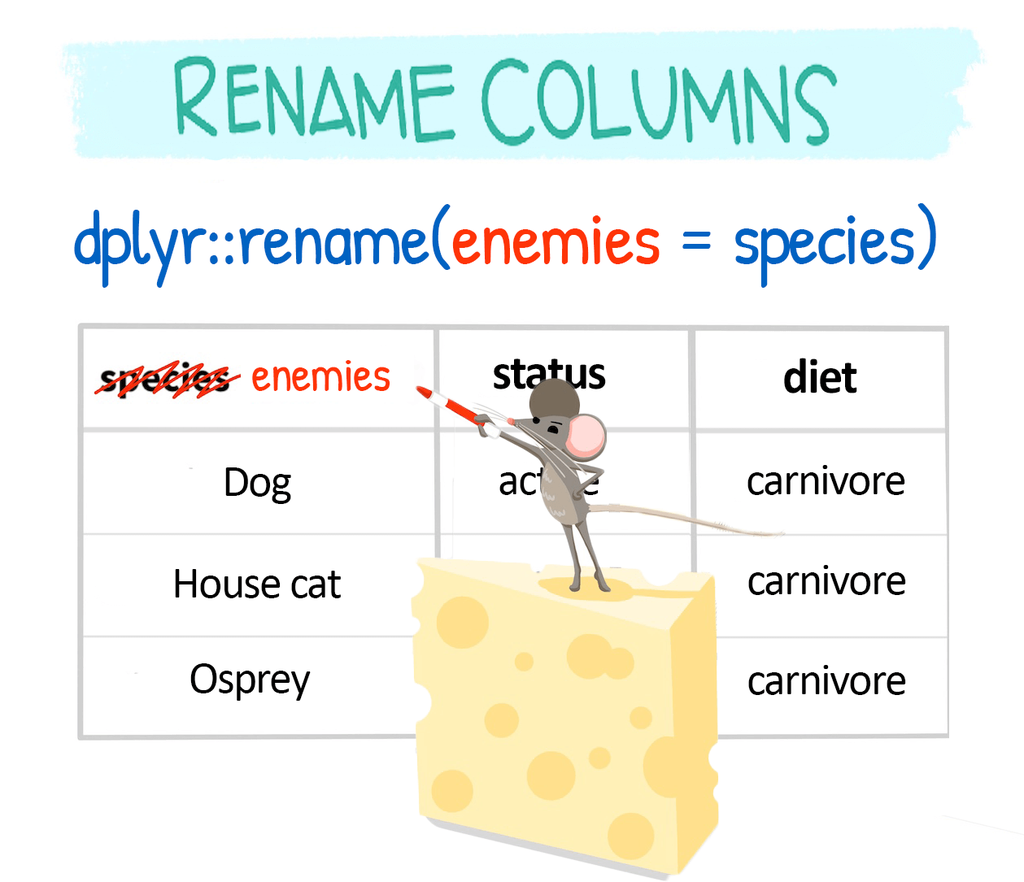

Fig: the `rename()` function. (Drawing adapted from Allison Horst)

[`dplyr::rename()`](https://dplyr.tidyverse.org/reference/rename.html) is used to change column names:

```r
# Rename `age` and `sex` to `patient_age` and `patient_sex`
yaounde %>%
  rename(patient_age = age,
         patient_sex = sex)
```

```
## # A tibble: 5 × 53
##   id                  date_surveyed patient_age age_category
##   <chr>               <date>              <dbl> <chr>
## 1 BRIQUETERIE_000_00… 2020-10-22             45 45 - 64
## 2 BRIQUETERIE_000_00… 2020-10-24             55 45 - 64
## 3 BRIQUETERIE_000_00… 2020-10-24             23 15 - 29
## 4 BRIQUETERIE_002_00… 2020-10-22             20 15 - 29
## 5 BRIQUETERIE_002_00… 2020-10-22             55 45 - 64
## # … with 49 more variables: age_category_3 <chr>,
## #   patient_sex <chr>, highest_education <chr>, …
```

The fact that the new name comes first in the function (`rename(NEWNAME = OLDNAME)`) is sometimes confusing. You should get used to this with time.

## 6.1 Rename within `select()`

You can also rename columns while selecting them:

```r
# Select `age` and `sex`, and rename them to `patient_age` and `patient_sex`
yaounde %>%
  select(patient_age = age,
         patient_sex = sex)
```

```
## # A tibble: 5 × 2
##   patient_age patient_sex
##         <dbl> <chr>
## 1          45 Female
## 2          55 Male
## 3          23 Male
## 4          20 Female
## 5          55 Female
```

# Wrap Up !

I hope this first lesson has allowed you to see how intuitive and useful the {dplyr} verbs are! This is the first of a series of basic data wrangling verbs: see you in the next lesson to learn more.

[figure not shown]

Fig: Basic Data Wrangling Dplyr Verbs.

# Contributors

The following team members contributed to this lesson:

- [LAURE VANCAUWENBERGHE](https://thegraphcourses.org/members/lolovanco)  
  Data analyst, the GRAPH Network

  A firm believer in science for good, striving to ally programming, health and education
- [ANDREE VALLE CAMPOS](https://thegraphcourses.org/members/avallecam/)  
  R Developer and Instructor, the GRAPH Network

  Motivated by reproducible science and education
- [KENE DAVID NWOSU](https://thegraphcourses.org/members/kendavidn/)  
  Data analyst, the GRAPH Network

  Passionate about education

# References

Some material in this lesson was adapted from the following sources:

- Horst, A. (2021). *Dplyr-learnr*. https://github.com/allisonhorst/dplyr-learnr (Original work published 2020)
- *Subset columns using their names and types—Select*. (n.d.). Retrieved 31 December 2021, from https://dplyr.tidyverse.org/reference/select.html

Artwork was adapted from:

- Horst, A. (2021). *R & stats illustrations by Allison Horst*. https://github.com/allisonhorst/stats-illustrations (Original work published 2018)